# DATA100 Introduction to Data Analytics

Lecture 8: Logical Vectors

Agassi Iu

Wilfrid Laurier University

2026-10-20

# The question

## Do students who sleep less get lower grades, and does it depend on their program?

- We have a survey of **1,000 students**
- Today we answer this question, and learn Chapter 12 (logical vectors) *along the way*

## Answer

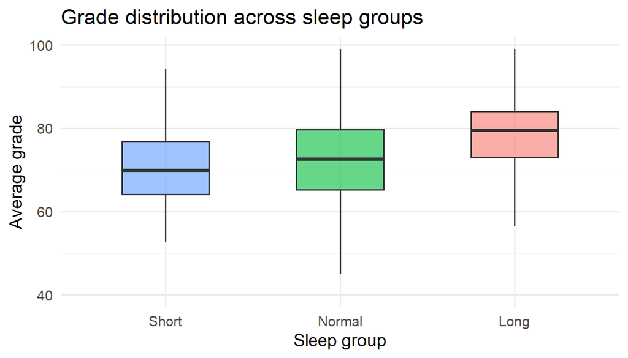

## Answer: split by program

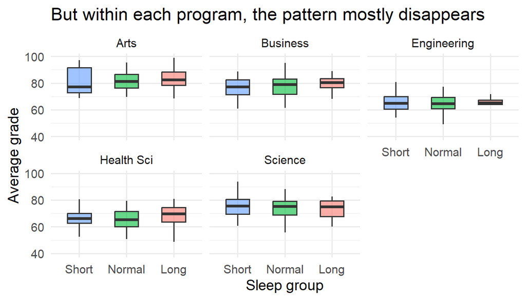

## So how did we get here?

Everything on the last two slides came from **one pipeline**:

```r
sleep_summary <- survey |>
  mutate(
    sleep_group = case_when(
      sleep_hours < 6    ~ "Short",
      sleep_hours <= 7.5 ~ "Normal",
      sleep_hours > 7.5  ~ "Long"
    )
  ) |>
  filter(!is.na(sleep_group), !is.na(avg_grade)) |>
  group_by(program, sleep_group) |>
  summarize(
    n = n(),
    mean_grade = mean(avg_grade),
    pct_passing = mean(avg_grade >= 60),
    any_fail = any(avg_grade < 50),
    .groups = "drop"
  )
```

## The plan for today

We rebuild the pipeline one action at a time.

Each action needs a different part of Chapter 12:

| Step | Action | Chapter 12 tools we need |
| --- | --- | --- |
| 1 | `mutate()` | comparisons (`<`, `==`), `if_else()`, `case_when()` |
| 2 | `filter()` | missing values, `is.na()`, `&`, `\|`, `!`, `%in%` |
| 3 | `group_by()` + `summarize()` | `sum()`, `mean()`, `any()`, `all()` |

**Not everything fits in this 80-minute lecture**

I may leave some of the undiscussed functions or tools in an *appendix table* at the end of the slide deck. Each row will say what the tool does and which section of the chapter to read. You should definitely take a look at the text for more details.

## Meet the data

**About this data**

- This is a **simulated** survey for teaching this class. Don’t take the results seriously.
- A blank cell means the student left the question unanswered. R reads it as `NA`
- You will see those blanks cause trouble in a few minutes

## What is a logical vector?

**Definition**

A logical vector is the simplest kind of vector: every element is exactly one of three values.

- `TRUE`
- `FALSE`
- `NA` (missing)
- Raw data rarely arrives as logical vectors
- But you will create and use them in almost every analysis

# Step 1: mutate()

## Where we are in the pipeline

```r
sleep_summary <- survey |>
  mutate(
    sleep_group = case_when(
      sleep_hours < 6    ~ "Short",
      sleep_hours <= 7.5 ~ "Normal",
      sleep_hours > 7.5  ~ "Long"
    )
  ) |>
  filter(!is.na(sleep_group), !is.na(avg_grade)) |>
  group_by(program, sleep_group) |>
  summarize(
    n = n(),
    mean_grade = mean(avg_grade),
    pct_passing = mean(avg_grade >= 60),
    any_fail = any(avg_grade < 50),
    .groups = "drop"
  )
```

**Goal:** turn `sleep_hours` (a number) into `sleep_group` (a categorical label).

## Modifying a column of data set

**`mutate()`**

This function adds new columns or modifies existing ones in a data frame. It operates column-wise and preserves the total number of rows.

```r
survey |>
  mutate(
    sleep_hours_week = sleep_hours * 7,
    high_sleep = sleep_hours > 7.5
  )
```

**Checkpoint**

What is the code from above trying to do?

## Creating logical vectors

The comparison operators are:

| Operator | Meaning |
| --- | --- |
| `<` | less than |
| `<=` | less than or equal to |
| `>` | greater than |
| `>=` | greater than or equal to |
| `==` | equal exactly to |
| `!=` | not equal to |

Each one compares two values and returns `TRUE` or `FALSE`.

## Who sleeps less than 6 hours?

- `short_sleep` is a logical column
- We can store it with `mutate()`, or use the same test directly inside `filter()`
- What is `.keep`?

## Choosing which columns survive

`mutate()` has a `.keep` argument that controls which columns appear in the result.

| `.keep =` | Columns returned |
| --- | --- |
| `"all"` (default) | All original columns plus the new ones |
| `"used"` | Only the columns used to build the new ones, plus the new ones |
| `"unused"` | Original columns you did not use, plus the new ones |
| `"none"` | Only the new columns (plus any grouping variables) |

**Why we use it today**

`.keep = "used"` shows each input column next to the logical column it produced, so you can check the result by eye. It does not change the logic.

## How many `TRUE`, `FALSE`, and `NA`?

**A blank is not FALSE**

Students who left `sleep_hours` blank get `NA`, not `FALSE`. *R* does not know whether they slept less than 6 hours.

- We deal with these rows in later in Step 2 `filter()`.

## Comparing text

**Spelling and capitals matter**

`"Yes"`, `"yes"`, and `"YES"` are three different values to R. Check how your data is spelled before you compare it. We will look at how we deal with text (strings) next class.

## Assigning labels using Logicals

**`if_else(condition, true, false)`**

This function picks one value when the `condition` is `TRUE` and another when it is `FALSE`.

- A blank `sleep_hours` stays `NA`
- This works for two groups (`TRUE` vs `FALSE` conditions)

## What if we want three groups?

**Piecewise functions**

We could nest one `if_else()` inside another. Every extra group adds another layer.

- It works, but it is already hard to read: time for `case_when()`

## `case_when()`

- Inspired by SQL’s `CASE` statement
- Uses a special syntax unlike anything else in the tidyverse: pairs of `condition ~ output`
- `condition` must be a logical vector; when it is `TRUE`, `output` is used

## Why “Normal” has no lower bound

**Only the first match is used**

If several conditions are `TRUE` for one student, `case_when()` uses the **first** one.

- A student with `sleep_hours = 5` is `< 6` **and** `<= 7.5`
- The `"Short"` line comes first, so it wins
- That is why `"Normal"` does not need to say `sleep_hours >= 6`

## What if we swap the order?

**Overlapping conditions**

## `.default` is a catch-all, and a trap

**Where did the NA row go?**

## Exercise 1

**Live exercise**

Use `case_when()` to create a `grade_band` column from `avg_grade`:

- `"Fail"`: below 50
- `"Pass"`: 50 to 69
- `"Good"`: 70 to 84
- `"Excellent"`: 85 and above

Then use `count()` to see how many students are in each band. What happens to students with a blank `avg_grade`?

# Step 2: filter()

## Where we are in the pipeline

```r
sleep_summary <- survey |>
  mutate(
    sleep_group = case_when(
      sleep_hours < 6    ~ "Short",
      sleep_hours <= 7.5 ~ "Normal",
      sleep_hours > 7.5  ~ "Long"
    )
  ) |>
  filter(!is.na(sleep_group), !is.na(avg_grade)) |>
  group_by(program, sleep_group) |>
  summarize(
    n = n(),
    mean_grade = mean(avg_grade),
    pct_passing = mean(avg_grade >= 60),
    any_fail = any(avg_grade < 50),
    .groups = "drop"
  )
```

**Goal:** remove the students with blank answers. This one line needs the most Chapter 12 ideas.

## `filter()` keeps `TRUE` rows

**Key idea**

`filter()` keeps rows where the condition is `TRUE`. It drops rows where the condition is `FALSE` **or `NA`**.

- Students with a blank `sleep_hours` are silently gone
- Is that what we wanted?

## Missing values are “contagious”

- `NA` stands for the *unknown*
- Almost any operation involving an unknown value gives an unknown result

## Let’s find the blank rows

- `sleep_hours == NA` returns `NA` for **every** row
- `filter()` drops rows where the condition is `NA`
- So nothing is left

## The fix: `is.na()`

**Key idea**

Never test for missing values with `== NA`. Use `is.na()`.

`is.na(x)` works on any type of vector. It returns `TRUE` for missing values and `FALSE` for everything else.

## Keeping the complete rows

- `!is.na(x)` reads as “x is **not** missing”
- This is the first half of our pipeline’s `filter()` line

## Combining logical vectors

Once you have several logical vectors, combine them with Boolean algebra:

| Operator | Meaning |
| --- | --- |
| `&` | and |
| `\|` | or |
| `!` | not |

- In `filter()`, a comma means the same as `&`: `filter(a, b)` is `filter(a & b)`
- That is why our pipeline has `filter(!is.na(sleep_group), !is.na(avg_grade))`

## Venn diagrams

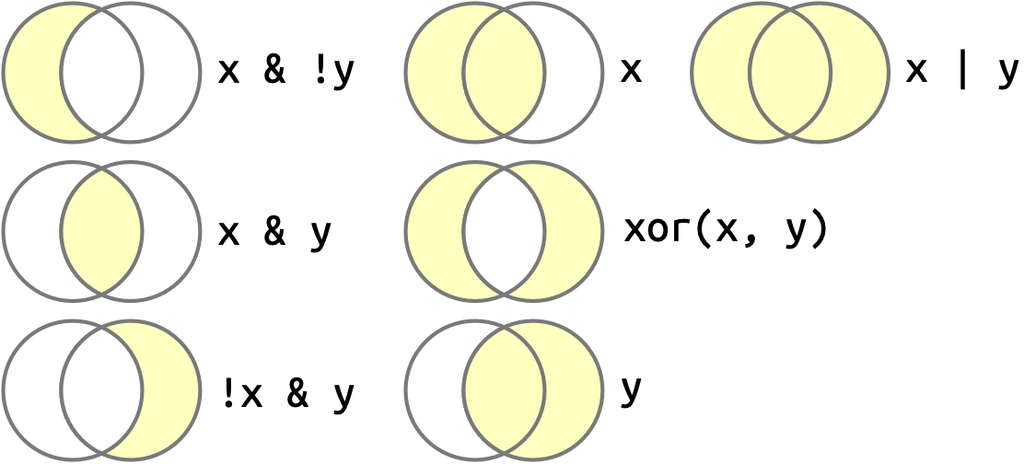

Common Boolean operations. `x` is the left circle, `y` is the right circle, and the shaded region shows what each operator selects. Figure from R for Data Science (2e), Fig. 12.1.

## Making sense of the `NA` rules

Remember: an `NA` in a logical vector means “could be `TRUE` or `FALSE`”.

**Or (`|`): only one side needs to be `TRUE`**

- `TRUE | TRUE` and `FALSE | TRUE` are both `TRUE`
- So `NA | TRUE` must be `TRUE`: whichever way the `NA` resolves, the result is `TRUE`
- But `NA | FALSE` is `NA`: it depends on what the `NA` really is

**And (`&`): both sides must be `TRUE`**

- `NA & TRUE` is `NA`: it depends on the `NA`
- `NA & FALSE` is `FALSE`: at least one side is `FALSE` no matter what

## R does not work like English

**A tempting mistake**

Suppose we want the high-stress students: stress level 4 **or** 5. In English that is easy to say…

## What went wrong?

1. R first evaluates `stress_level == 4`, producing a logical vector (call it `four`)
2. Then it computes `four | 5`
3. With a logical operator, any number other than 0 is converted to `TRUE`
4. So this becomes `four | TRUE`, which is **always** `TRUE`
5. Every row is selected

## The same mistake with text

**Loud errors are the friendly ones**

With numbers, the mistake is **silent** and gives wrong results. With text, *R* basically stops and complains. Either way, *R* does not read English the way we do, so you should write the full comparison on both sides.

## Is this in my vector?

**`x %in% y`**

This returns a logical vector the same length as `x`. It is `TRUE` whenever a value of `x` appears anywhere in `y`.

## `%in%` and missing values

**Different NA rules**

`%in%` follows different `NA` rules from `==`: `NA %in% NA` is `TRUE`.

## Back to the pipeline

By now we have removed the missing data under the columns with categorical variable with `sleep_hours` (i.e. `sleep_group`), and `avg_grade`.

- Why do we also drop blank `avg_grade`? The next step averages it!

## Exercise 2

**Live exercise**

1. How many students left `sleep_hours` blank? Then count the blanks in every column.
2. Find students in Arts or Business who sleep less than 6 hours. Use `%in%`.
3. Find the same students again, this time using `|`.

# Step 3: group_by( ) and summarize( )

## Where we are in the pipeline

```r
sleep_summary <- survey |>
  mutate(
    sleep_group = case_when(
      sleep_hours < 6    ~ "Short",
      sleep_hours <= 7.5 ~ "Normal",
      sleep_hours > 7.5  ~ "Long"
    )
  ) |>
  filter(!is.na(sleep_group), !is.na(avg_grade)) |>
  group_by(program, sleep_group) |>
  summarize(
    n = n(),
    mean_grade = mean(avg_grade),
    pct_passing = mean(avg_grade >= 60),
    any_fail = any(avg_grade < 50),
    .groups = "drop"
  )
```

**Goal:** one row per program and sleep group, with a few summary numbers.

## Key Functions Here

**`group_by()`**

This function changes the unit of analysis by organizing rows into groups. It is invisible on its own, but changes how subsequent functions operate.

**`summarize()`**

This function collapses multiple rows down into a single summary statistic per group.

```r
# Example: Calculate student counts and mean grades by program
survey |>
  group_by(program) |>
  summarize(
    n = n(),
    mean_grade = mean(avg_grade, na.rm = TRUE)
  )
```

## Summaries of logical vectors

In a numeric context, `TRUE` becomes **1** and `FALSE` becomes **0**.

**Key idea**

- `sum(x)` gives the **number** of `TRUE`s
- `mean(x)` gives the **proportion** of `TRUE`s (because `mean()` is just `sum()` divided by `length()`)

## `sum()` and `mean()` by program

How many students in each program sleep under 6 hours, and what proportion is that?

## Remember the `NA`s

**Without na.rm**

**na.rm changes the denominator**

`mean(x < 6, na.rm = TRUE)` is the proportion **among students who answered**. It does not count blank rows as `FALSE`. In our pipeline, we avoid the problem by filtering the blank rows out first.

## `any()` and `all()`

- `any(x)` is the equivalent of `|`: `TRUE` if there is at least one `TRUE` in `x`
- `all(x)` is the equivalent of `&`: `TRUE` only if **every** value of `x` is `TRUE`
- Like most summary functions, add `na.rm = TRUE` to drop missing values
- Often `any()` and `all()` are a bit too crude
- We usually want to know *how many*, which is why `sum()` and `mean()` come first

## Putting it together

**Watch the group sizes**

## Exercise 3

**Live exercise**

For each program, find:

- `n_short`: how many students sleep under 6 hours
- `prop_short`: the proportion of students who sleep under 6 hours
- `prop_early`: the proportion who have an early class (`has_early_class == "Yes"`)
- `any_high`: whether any student has `avg_grade` of 95 or above

# Wrap-up

## Back to the question

> Do students who sleep less get lower grades, and does it depend on their program?
- Overall: students who sleep more have higher average grades
- Within each program:** the differences are small and not consistent
- Why: programs differ in both sleep and grades, so mixing them together created the overall pattern

**Caution: What we cannot say**

- This is survey data, so it shows *association*, not cause
- Some groups are small, so differences of a point or two mean little
- A good analyst checks the group sizes before telling a story

## Chapter summary

A logical vector is simple (each value is `TRUE`, `FALSE`, or `NA`), but it is very powerful.

- Create them with `>`, `<`, `<=`, `>=`, `==`, `!=`, and `is.na()`
- Combine them with `!`, `&`, and `|`
- Summarize them with `any()`, `all()`, `sum()`, and `mean()`
- Transform conditionally with `if_else()` and `case_when()`

## What’s next

Logical vectors will keep coming back:

- In Chapter 14 (Strings), `str_detect(x, pattern)` returns a logical vector that is `TRUE` where elements of `x` match the `pattern`
- In Chapter 17 (Dates and times), you will build logical vectors by comparing dates and times

**Up Next**

**Numbers and Strings**. The survey has a `bedtime` column where students typed their bedtime in many different ways. We will clean it up.